# Geospatial Risk Prediction

Anushka Samant

2023-10-10

```r
knitr::opts_chunk$set(echo = TRUE, warning = FALSE, message = FALSE, fig.align = 'left')

library(tidyverse)
library(sf)
library(RSocrata)
library(viridis)
library(spatstat.explore)
library(spatstat)
library(raster)
library(spdep)
library(FNN)
library(grid)
library(gridExtra)
library(knitr)
library(kableExtra)
library(tidycensus)
library(conflicted)
library(classInt)
library(dplyr)
conflicts_prefer(dplyr::filter)

library(scales)
#show_col(scales::viridis_pal()(20))
#q_colors =  15 # for no particular reason

# functions
root.dir = "https://raw.githubusercontent.com/urbanSpatial/Public-Policy-Analytics-Landing/master/DATA/"
source("https://raw.githubusercontent.com/urbanSpatial/Public-Policy-Analytics-Landing/master/functions.r")
```

## Introduction

The city of Chicago, like many urban centers, faces a set of challenges when it comes to understanding and addressing cannabis-related crimes. The recent changes in cannabis legislation, both at the state and local levels, have brought about significant shifts in how these crimes are perceived, reported, and managed. This introduction delves into the specific context of cannabis crimes in Chicago and the potential influence of selection bias in the data related to these offenses.

Cannabis-related crimes encompass a wide range of offenses, including possession, distribution, and illegal cultivation. These crimes are often non-violent and can vary in severity. Understanding the spatial distribution and patterns of these offenses is crucial for effective law enforcement and public safety efforts.

In the context of cannabis crimes, selection bias can manifest in several ways:

- **Over-Policing:** Certain communities may experience higher levels of police presence and enforcement, leading to increased reporting of cannabis-related offenses in these areas.
- **Reporting Bias:** Not all crimes are reported to the police, and the likelihood of reporting can vary by factors such as the type of crime, neighborhood, and demographics. This can result in underreporting or overreporting of certain types of crimes.
- **Demographic Bias:** There can be racial, gender, or age biases in crime reporting. Some groups may be overrepresented or underrepresented in the data.
- **Law Enforcement Practices:** Policing strategies, priorities, and resources can vary by neighborhood, potentially leading to variations in the reporting and recording of cannabis crimes.

## Data

The primary geospatial data source for this analysis is derived from the City of Chicago’s open data portal.

```r
policeDistricts <-
  st_read("https://data.cityofchicago.org/api/geospatial/fthy-xz3r?method=export&format=GeoJSON") %>%
  st_transform('ESRI:102271') %>%
  dplyr::select(District = dist_num)

policeBeats <-
  st_read("https://data.cityofchicago.org/api/geospatial/aerh-rz74?method=export&format=GeoJSON") %>%
  st_transform('ESRI:102271') %>%
  dplyr::select(District = beat_num)

bothPoliceUnits <- rbind(mutate(policeDistricts, Legend = "Police Districts"),
                         mutate(policeBeats, Legend = "Police Beats"))

chicagoBoundary <-
  st_read(file.path(root.dir,"/Chapter5/chicagoBoundary.geojson")) %>%
  st_transform('ESRI:102271')

bothPoliceUnits <- rbind(mutate(policeDistricts, Legend = "Police Districts"),
                         mutate(policeBeats, Legend = "Police Beats"))

#crimes <- read.socrata("https://data.cityofchicago.org/Public-Safety/Crimes-2017/d62x-nvdr")
#unique(crimes$Primary.Type)
#table(crimes$Primary.Type)
```

## Feature Engineering

In this section we use spatial analytics and feature engineering to perform initial analysis for the subsequent spatial risk modeling analysis. In the “Crimes” dataset, the spatial distribution of cannabis-related crimes is analyzed and subsequently refined via grid cell aggregation using “fishnet”. For the “Risk Factors,” a grid cell-based aggregation is carried out for various risk factor data, and the feature set is enriched with calculated distances to neighboring risk factors and a significance variable representing the distance to Chicago’s Central Business District.

### Crimes

The maps reveal distinct spatial patterns of cannabis-related crimes in Chicago during 2017.

The first map demonstrates the locations of these crimes, marked in blue, superimposed on the city’s boundaries. Notably, cannabis-related incidents appear to cluster in specific regions, suggesting that certain areas within Chicago experienced higher rates of these offenses.

The second visualization depicts the density of these crimes, with more intense colors indicating areas of greater concentration. It’s evident that the highest densities align with the previously identified clusters, emphasizing the spatial heterogeneity in cannabis-related crime distribution.

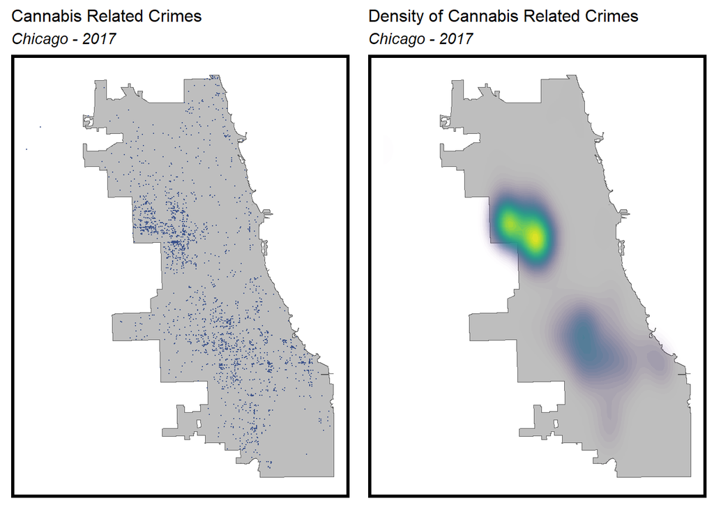

```r
narc <- read.socrata("https://data.cityofchicago.org/Public-Safety/Crimes-2017/d62x-nvdr") %>%
  dplyr::filter(Primary.Type == "NARCOTICS" & str_detect(Description, "CANNABIS")) %>%
  dplyr::filter(!is.na(Location) & str_detect(Location, "\\d+,\\s*-?\\d+")) %>%
  mutate(x = gsub("[()]", "", Location)) %>%
  separate(x, into = c("Y", "X"), sep = ",") %>%
  mutate(X = as.numeric(X), Y = as.numeric(Y)) %>%
  na.omit() %>%
  st_as_sf(coords = c("X", "Y"), crs = 4326, agr = "constant") %>%
  st_transform('ESRI:102271') %>%
  distinct()

grid.arrange(ncol=2,
ggplot() +
  geom_sf(data = chicagoBoundary, fill = "grey") +
  geom_sf(data = narc, colour="#3b528b", size = 0.1, show.legend = "point") +
  labs(title= "Cannabis Related Crimes", subtitle = "Chicago - 2017") +
  mapTheme(title_size = 12),

ggplot() +
  geom_sf(data = chicagoBoundary, fill = "grey") +
  stat_density2d(data = data.frame(st_coordinates(narc)),
                 aes(X, Y, fill = ..level.., alpha = ..level..),
                 size = 0.01, bins = 40, geom = 'polygon') +
  scale_fill_viridis() +
  scale_alpha(range = c(0.00, 0.35), guide = FALSE) +
  labs(title = "Density of Cannabis Related Crimes", subtitle = "Chicago - 2017") +
  mapTheme(title_size = 12) + theme(legend.position = "none"))
```

Our next step involves utilizing grid cells as the basis for our analysis, allowing us to aggregate individual data points within a polygonal context. In this process, we have generated a fishnet comprising grid cells measuring 500 feet by 500 feet, which is constrained by the city’s boundaries. Within each of these grid cells, we have tabulated the count of crimes.

The resulting plot reflects a spatial distribution similar to the density map presented earlier, highlighting two prominent hotspots of narcotics-related crimes within the city of Chicago.

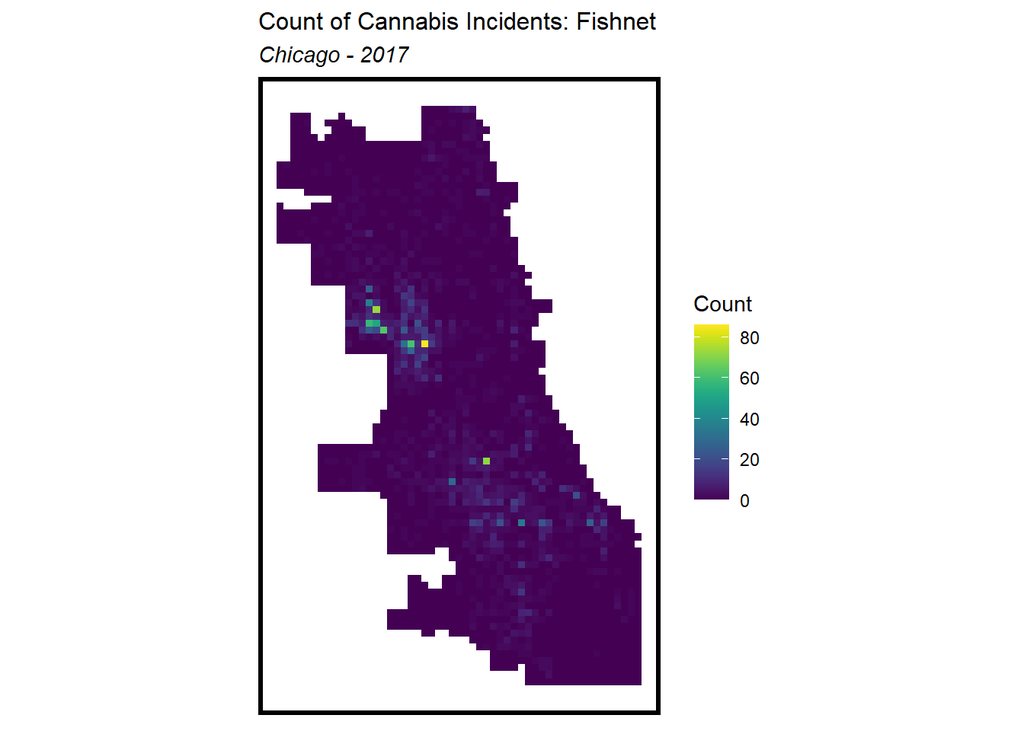

```r
## using {sf} to create the grid
## Note the `.[chicagoBoundary] %>% ` line. This is needed to clip the grid to our data
fishnet <-
  st_make_grid(chicagoBoundary,
               cellsize = 500,
               square = TRUE) %>%
  .[chicagoBoundary] %>%            # fast way to select intersecting polygons
  st_sf() %>%
  mutate(uniqueID = 1:n())

narc_net <-
  dplyr::select(narc) %>%
  mutate(countNarc = 1) %>%
  aggregate(., fishnet, sum) %>%
  mutate(countNarc = replace_na(countNarc, 0),
         uniqueID = 1:n(),
         cvID = sample(round(nrow(fishnet) / 24),
                       size=nrow(fishnet), replace = TRUE))

ggplot() +
  geom_sf(data = narc_net, aes(fill = countNarc), color = NA) +
  scale_fill_viridis() +
  labs(title = "Count of Cannabis Incidents: Fishnet", subtitle = "Chicago - 2017", fill = "Count") +
  mapTheme(title_size = 12)
```

### Risk Factors

We use five risk factors through data downloads from the Chicago Open Data site, containing the locations of 311 Service Requests related to (1) vacant and abandoned buildings, (2) abandoned cars, (3) graffiti, (4) non-functional street lights, and (5) non-functional alley lights.

Beyond the 311 call data, our data set also includes the spatial information of public parks, police stations, affordable housing, and L Stops. To synthesize these risk factors effectively, we employ a grid cell approach to aggregate their counts within specific grid cells.

While this approach provides a structured spatial scale of exposure, we have introduced additional features to create a more nuanced exposure relationship across space. Specifically, we calculate the average distance to the three nearest neighboring instances of each of the aforementioned risk factors.This addition helps hypothesize a smoother and more continuous spatial exposure profile.

Another variable we incorporate into our dataset is the distance to the centroid of the Loop, which serves as Chicago’s Central Business District. We assume that these variables interact with crimes and will increase the comprehensiveness of our geospatial risk model.

```r
abandonBldg <-
  read.socrata("https://data.cityofchicago.org/Service-Requests/311-Service-Requests-Vacant-and-Abandoned-Building/7nii-7srd") %>%
    mutate(year = substr(date_service_request_was_received,1,4)) %>% dplyr::filter(year == "2017") %>%
    dplyr::select(Y = latitude, X = longitude) %>%
    na.omit() %>%
    st_as_sf(coords = c("X", "Y"), crs = 4326, agr = "constant") %>%
    st_transform(st_crs(fishnet)) %>%
    mutate(Legend = "Abandoned_Buildings")

abandonCars <-
  read.socrata("https://data.cityofchicago.org/Service-Requests/311-Service-Requests-Abandoned-Vehicles/3c9v-pnva") %>%
    mutate(year = substr(creation_date,1,4)) %>% dplyr::filter(year == "2017") %>%
    dplyr::select(Y = latitude, X = longitude) %>%
    na.omit() %>%
    st_as_sf(coords = c("X", "Y"), crs = 4326, agr = "constant") %>%
    st_transform(st_crs(fishnet)) %>%
    mutate(Legend = "Abandoned_Cars")

graffiti <-
  read.socrata("https://data.cityofchicago.org/Service-Requests/311-Service-Requests-Graffiti-Removal-Historical/hec5-y4x5") %>%
    mutate(year = substr(creation_date,1,4)) %>% dplyr::filter(year == "2017") %>%
    dplyr::filter(where_is_the_graffiti_located_ %in% c("Front", "Rear", "Side")) %>%
    dplyr::select(Y = latitude, X = longitude) %>%
    na.omit() %>%
    st_as_sf(coords = c("X", "Y"), crs = 4326, agr = "constant") %>%
    st_transform(st_crs(fishnet)) %>%
    mutate(Legend = "Graffiti")

streetLightsOut <-
  read.socrata("https://data.cityofchicago.org/Service-Requests/311-Service-Requests-Street-Lights-All-Out/zuxi-7xem") %>%
    mutate(year = substr(creation_date,1,4)) %>% dplyr::filter(year == "2017") %>%
    dplyr::select(Y = latitude, X = longitude) %>%
    na.omit() %>%
    st_as_sf(coords = c("X", "Y"), crs = 4326, agr = "constant") %>%
    st_transform(st_crs(fishnet)) %>%
    mutate(Legend = "Street_Lights_Out")

alleyLightsOut <-
  read.socrata("https://data.cityofchicago.org/Service-Requests/311-Service-Requests-Alley-Lights-Out-No-Duplicate/up7z-t43p") %>%
  mutate(year = substr(Creation.Date,1,4)) %>% dplyr::filter(year == "2017") %>%
  dplyr::select(Y = Latitude, X = Longitude) %>%
  na.omit() %>%
  st_as_sf(coords = c("X", "Y"), crs = 4326, agr = "constant") %>%
  st_transform(st_crs(fishnet)) %>%
  mutate(Legend = "Alley_Lights_Out")

parks_transform <- st_read("E:/Downloads/Parks - Chicago Park District Park Boundaries (current).geojson") %>%
  st_make_valid() %>%
  st_centroid()
coordinates <- st_coordinates(parks_transform)
parks_transform$longitude <- coordinates[, "X"]
parks_transform$latitude <- coordinates[, "Y"]
parks<- parks_transform %>%
  dplyr::select(Y = latitude, X = longitude) %>%
  na.omit() %>%
  st_as_sf(coords = c("X", "Y"), crs = 4326, agr = "constant") %>%
  st_transform(st_crs(fishnet)) %>%
  mutate(Legend = "Parks") %>%
  dplyr::select(-X, -Y)

policeStations <-
  read.socrata("https://data.cityofchicago.org/Public-Safety/Police-Stations/z8bn-74gv") %>%
    # mutate(year = substr(creation_date,1,4)) %>% filter(year == "2017") %>%
    dplyr::select(Y = latitude, X = longitude) %>%
    na.omit() %>%
    st_as_sf(coords = c("X", "Y"), crs = 4326, agr = "constant") %>%
    st_transform(st_crs(fishnet)) %>%
    mutate(Legend = "Police_Stations")

affordableHousing <-
    read.socrata("https://data.cityofchicago.org/Community-Economic-Development/Affordable-Rental-Housing-Developments/s6ha-ppgi") %>%
    # mutate(year = substr(creation_date,1,4)) %>% filter(year == "2017") %>%
    dplyr::select(Y = latitude, X = longitude) %>%
    na.omit() %>%
    st_as_sf(coords = c("X", "Y"), crs = 4326, agr = "constant") %>%
    st_transform(st_crs(fishnet)) %>%
    mutate(Legend = "Affordable_Housing")

Lstops <- read.socrata("https://data.cityofchicago.org/Transportation/CTA-System-Information-List-of-L-Stops/8pix-ypme") %>%
  dplyr::filter(!is.na(location)) %>%  # Remove rows with missing location
  mutate(
    latitude = as.numeric(gsub(".*\\((.*),.*\\)", "\\1", location)),
    longitude = as.numeric(gsub(".*,\\s*(.*)\\)", "\\1", location))
  ) %>%
  dplyr::filter(!is.na(latitude) & !is.na(longitude)) %>%  # Remove rows with missing latitude or longitude
  dplyr::select(Y = latitude, X = longitude) %>%
  st_as_sf(coords = c("X", "Y"), crs = 4326, agr = "constant") %>%
  st_transform(st_crs(fishnet)) %>%
  mutate(Legend = "L_Stops")
```

```r
## Neighborhoods to use in LOGOCV in a bit
neighborhoods <-
  st_read("https://raw.githubusercontent.com/blackmad/neighborhoods/master/chicago.geojson") %>%
  st_transform(st_crs(fishnet))

vars_net <-
  rbind(abandonCars,
        abandonBldg,
        streetLightsOut,
        policeStations,
        graffiti,
        alleyLightsOut,
        affordableHousing,
        Lstops,
        parks) %>%
  st_join(., fishnet, join=st_within) %>%
  st_drop_geometry() %>%
  group_by(uniqueID, Legend) %>%
  summarize(count = n()) %>%
  left_join(fishnet, ., by = "uniqueID") %>%
  spread(Legend, count, fill=0) %>%
  dplyr::select(-`<NA>`) %>%
  ungroup()

vars_net <- vars_net %>%
  mutate(Abandoned_Cars.nn = nn_function(st_coordinates(st_centroid(vars_net)), st_coordinates(abandonCars), k = 3),
         Abandoned_Buildings.nn = nn_function(st_coordinates(st_centroid(vars_net)), st_coordinates(abandonBldg), k = 3),
         Street_Lights_Out.nn = nn_function(st_coordinates(st_centroid(vars_net)), st_coordinates(streetLightsOut), k = 3),
         Graffiti.nn = nn_function(st_coordinates(st_centroid(vars_net)), st_coordinates(graffiti), k = 3),
         Alley_Lights_Out.nn = nn_function(st_coordinates(st_centroid(vars_net)), st_coordinates(alleyLightsOut), k = 3),
         parks.nn = nn_function(st_coordinates(st_centroid(vars_net)), st_coordinates(parks), k = 3),
         policeStations.nn = nn_function(st_coordinates(st_centroid(vars_net)), st_coordinates(policeStations), k = 3),
         Lstops.nn = nn_function(st_coordinates(st_centroid(vars_net)), st_coordinates(Lstops), k = 3),
         affordableHousing.nn = nn_function(st_coordinates(st_centroid(vars_net)), st_coordinates(affordableHousing), k = 3)
)

vars_net$Loop_Distance <-
  st_distance(st_centroid(vars_net), dplyr::filter(neighborhoods, name == "Loop") %>% st_centroid()) %>%
  as.numeric()

final_net <-
  left_join(narc_net, st_drop_geometry(vars_net), by="uniqueID")

final_net <-
  st_centroid(final_net) %>%
    st_join(dplyr::select(neighborhoods, name), by = "uniqueID") %>%
    st_join(dplyr::select(policeDistricts, District), by = "uniqueID") %>%
      st_drop_geometry() %>%
      left_join(dplyr::select(final_net, geometry, uniqueID)) %>%
      st_sf() %>%
  na.omit()
```

Here is the compilation of maps for all risk factors by fishnet.

As shown in the map, the grid cell counts are more granular and the nearest neighbors risk factors provide smoother variations across space.

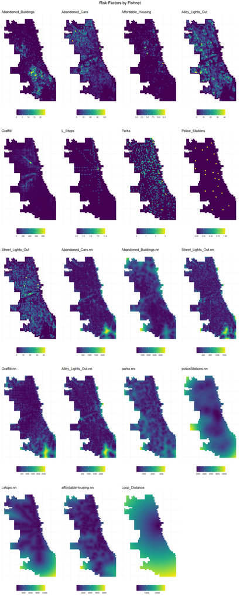

```r
vars_net.long <-
  gather(vars_net, Variable, value, -geometry, -uniqueID)
vars <- unique(vars_net.long$Variable)
mapList <- list()

for (i in vars) {
  mapList[[i]] <-
    ggplot() +
    geom_sf(data = dplyr::filter(vars_net.long, Variable == i), aes(fill = value), colour = NA) +
    scale_fill_viridis(name = "") +
    labs(title = i) +
    theme_minimal(base_size = 7) +
    theme(
      axis.text = element_blank(),  # Remove latitude and longitude labels
      axis.title = element_blank(),  # Remove axis titles
      plot.title = element_text(size = 10),
      legend.position = "bottom"
    )
}

do.call(grid.arrange,c(mapList, ncol = 4, top = "Risk Factors by Fishnet"))
```

## Spatial Analysis

### Local Moran’s I

In order to examine the localized spatial patterns of narcotics-related crimes, we employ a statistical measure known as Local Moran’s I. This test helps us determine whether the distribution of narcotics counts at specific locations is random concerning their nearby neighbors or if there exists a noteworthy spatial clustering of these crimes.

```r
set.ZeroPolicyOption(TRUE)
final_net.nb <- poly2nb(as_Spatial(final_net), queen=TRUE)
final_net.weights <- nb2listw(final_net.nb, style="W", zero.policy=TRUE)

## see ?localmoran
local_morans <- localmoran(final_net$countNarc, final_net.weights, zero.policy=TRUE) %>%
  as.data.frame()

# join local Moran's I results to fishnet
final_net.localMorans <-
  cbind(local_morans, as.data.frame(final_net)) %>%
  st_sf() %>%
  dplyr::select(Narcotics_Count = countNarc,
                Local_Morans_I = Ii,
                P_Value = `Pr(z != E(Ii))`) %>%
  mutate(Significant_Hotspots = ifelse(P_Value <= 0.05, 1, 0)) %>%
  gather(Variable, Value, -geometry)
```

The following maps illustrate that relatively higher Moran’s-I values provide strong and statistically significant indications of local clustering. This is also observed in the p-value and significant hotspot maps.

As a result, we introduce two novel spatial process variables aimed at capturing this spatial phenomenon.

- **`narc.isSig`** is a binary variable that identifies a cell as part of a significant cluster if its p-value is less than or equal to 0.0000001.
- **`narc.isSig.dist`** measures the average distance from the centroid of each cell to its nearest significant cluster, providing insights into spatial patterns and relationships in the data.

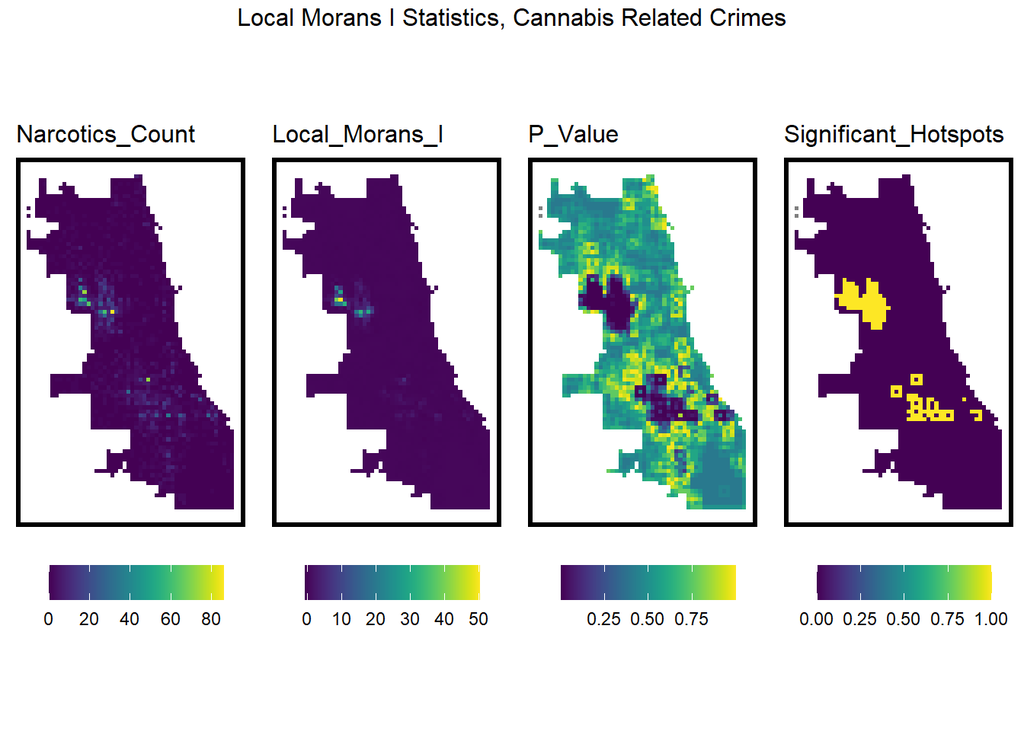

```r
vars <- unique(final_net.localMorans$Variable)
varList <- list()

for(i in vars){
  varList[[i]] <-
    ggplot() +
      geom_sf(data = filter(final_net.localMorans, Variable == i),
              aes(fill = Value), colour=NA) +
      scale_fill_viridis(name="") +
      labs(title=i) +
      mapTheme(title_size = 12) + theme(legend.position="bottom")}

do.call(grid.arrange,c(varList, ncol = 4, top = "Local Morans I Statistics, Cannabis Related Crimes"))
```

```r
final_net <-
  final_net %>%
  mutate(narc.isSig =
           ifelse(localmoran(final_net$countNarc,
                             final_net.weights)[,5] <= 0.0000001, 1, 0)) %>%
  mutate(narc.isSig.dist =
           nn_function(st_coordinates(st_centroid(final_net)),
                       st_coordinates(st_centroid(
                         filter(final_net, narc.isSig == 1))), 1))
```

### Correlation

To gain insights into which variables might influence the number of cannabis-related crimes and facilitate the process of selecting relevant features, we generate a series of scatterplots. These scatterplots depict the relationship between cannabis crime counts within grid cells and the independent variables.

When considering a specific risk factor, we carefully choose between utilizing either the count or nearest neighbor features to prevent issues of collinearity.

Several factors exhibit correlations with the count of cannabis-related crimes in Chicago in 2017:

**Moderate Positive Correlations:** Areas with more abandoned buildings and non-functional alley lights are moderately positively correlated with increased cannabis-related crimes.

**Negative Correlations:** Nearest neighbors of areas with various risk factors (e.g., abandoned buildings, cars, graffiti, alley lights, parks, and affordable housing) tend to have negative correlations with cannabis-related crimes, suggesting lower crime counts in these neighboring areas.

Overall, while significant cannabis-related incidents and certain urban services indicators show stronger associations with higher cannabis-related crimes, the role of other risk factors is relatively weaker or characterized by spatial relationships with neighboring areas.

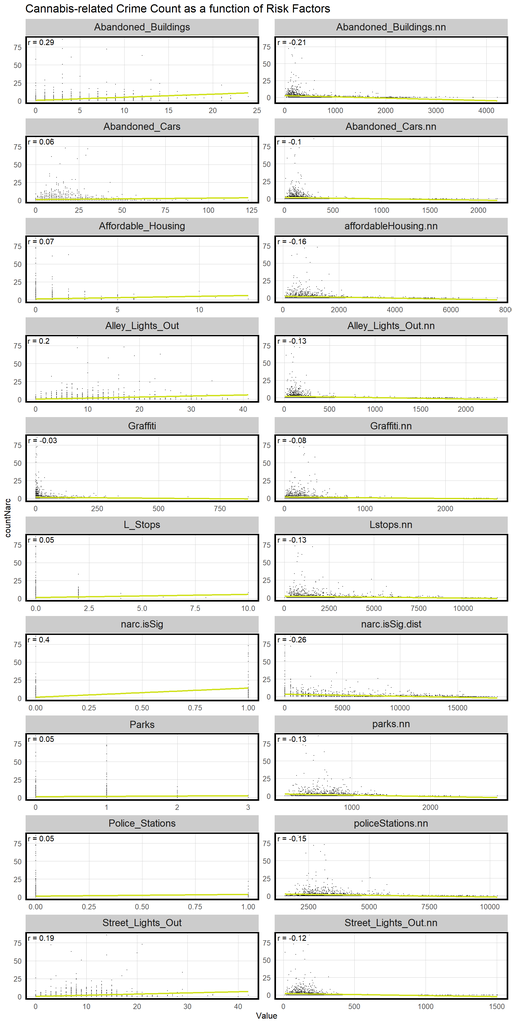

```r
correlation.long <-
  st_drop_geometry(final_net) %>%
    dplyr::select(-uniqueID, -cvID, -Loop_Distance, -name, -District) %>%
    gather(Variable, Value, -countNarc)

correlation.cor <-
  correlation.long %>%
    group_by(Variable) %>%
    summarize(correlation = cor(Value, countNarc, use = "complete.obs"))

ggplot(correlation.long, aes(Value, countNarc)) +
  geom_point(size = 0.1) +
  geom_text(data = correlation.cor, aes(label = paste("r =", round(correlation, 2))),
            x=-Inf, y=Inf, vjust = 1.5, hjust = -.1) +
  geom_smooth(method = "lm", se = FALSE, colour = "#d0e11c") +
  facet_wrap(~Variable, ncol = 2, scales = "free",  labeller = label_parsed, as.table = TRUE) +
  labs(title = "Cannabis-related Crime Count as a function of Risk Factors") +
  theme(strip.text = element_text(size = 9)) +
  plotTheme()
```

## Poisson Regression

In order to select an appropriate model for our variables, we examine the distribution of crime counts through a histogram. The histogram aligns with our expectations, displaying a highly skewed distribution where a majority of grid cells have no recorded crime events. This skewed distribution exhibits characteristics similar to a Poisson distribution. As a result, we decide to employ a Poisson Regression model to analyze this data.

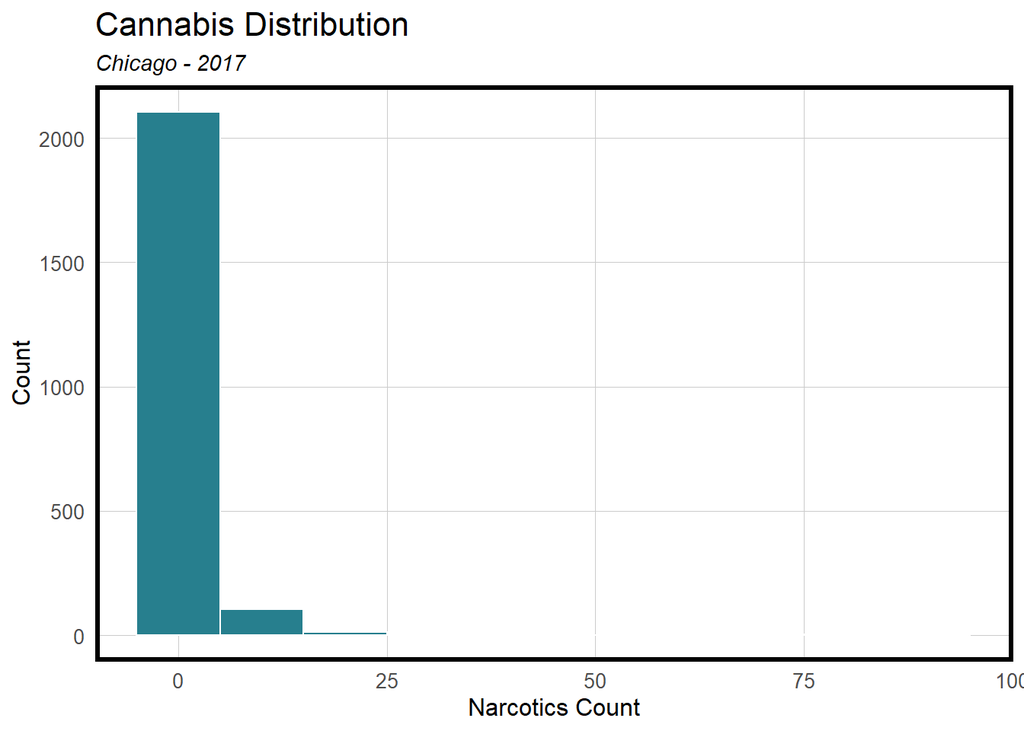

```r
ggplot(final_net) +
  geom_histogram(aes(x = countNarc), color="white", fill = "#277f8e", binwidth = 10) +
  labs(title = "Cannabis Distribution", x = "Narcotics Count", y = "Count", subtitle = "Chicago - 2017") +
  theme(plot.title = element_text(size = 12)) +
  plotTheme()
```

### Cross-validated Poisson Regression

Next, we employ cross-validation to assess the generalizability of our model. The concept involves setting aside one local area, training the model on the remaining `n - 1` areas, making predictions for the held-out area, and evaluating the model’s goodness of fit.

There are two methods for conducting cross-validation in this context: one is using a randomly generated **`cvID`** assigned to each grid cell for random k-fold cross-validation, referred to as **Random k-fold CV**, and the other is based on neighborhood names or police districts for spatial cross-validation, known as **Spatial LOGO-CV**.

We will compare the cross-validation results between **Random k-fold CV** and **Spatial LOGO-CV**, considering both the use of spatial process variables and their absence in the analysis.

```r
reg.ss.vars <- c("Abandoned_Cars.nn", "Abandoned_Buildings.nn", "Street_Lights_Out.nn", "Graffiti.nn", "parks.nn", "Lstops.nn", "affordableHousing.nn", "Alley_Lights_Out.nn",
              "Loop_Distance", "narc.isSig", "narc.isSig.dist")

reg.vars <- c("Abandoned_Cars.nn", "Abandoned_Buildings.nn", "Street_Lights_Out.nn", "Graffiti.nn", "parks.nn", "Lstops.nn", "affordableHousing.nn", "Alley_Lights_Out.nn", "Loop_Distance")


## RUN REGRESSIONS
reg.cv <- crossValidate(
  dataset = final_net,
  id = "cvID",
  dependentVariable = "countNarc",
  indVariables = reg.vars) %>%
    dplyr::select(cvID = cvID, countNarc, Prediction, geometry)

reg.ss.cv <- crossValidate(
  dataset = final_net,
  id = "cvID",
  dependentVariable = "countNarc",
  indVariables = reg.ss.vars) %>%
    dplyr::select(cvID = cvID, countNarc, Prediction, geometry)

reg.spatialCV <- crossValidate(
  dataset = final_net,
  id = "name",
  dependentVariable = "countNarc",
  indVariables = reg.vars) %>%
    dplyr::select(cvID = name, countNarc, Prediction, geometry)

reg.ss.spatialCV <- crossValidate(
  dataset = final_net,
  id = "name",
  dependentVariable = "countNarc",
  indVariables = reg.ss.vars) %>%
    dplyr::select(cvID = name, countNarc, Prediction, geometry)

reg.summary <-
  rbind(
    mutate(reg.cv,           Error = Prediction - countNarc,
                             Regression = "Random k-fold CV: Just Risk Factors"),

    mutate(reg.ss.cv,        Error = Prediction - countNarc,
                             Regression = "Random k-fold CV: Spatial Process"),

    mutate(reg.spatialCV,    Error = Prediction - countNarc,
                             Regression = "Spatial LOGO-CV: Just Risk Factors"),

    mutate(reg.ss.spatialCV, Error = Prediction - countNarc,
                             Regression = "Spatial LOGO-CV: Spatial Process")) %>%
    st_sf()
```

The figure presented below shows a spatial representation of the model errors.Within the **Spatial LOGO-CV** category, it becomes evident that the most significant errors are concentrated within the crime hotspot areas.

Incorporating the local spatial crime process substantially mitigates these errors in these specific regions. Conversely, in the **Random k-fold CV** group, the errors are more uniformly distributed across the spatial landscape.

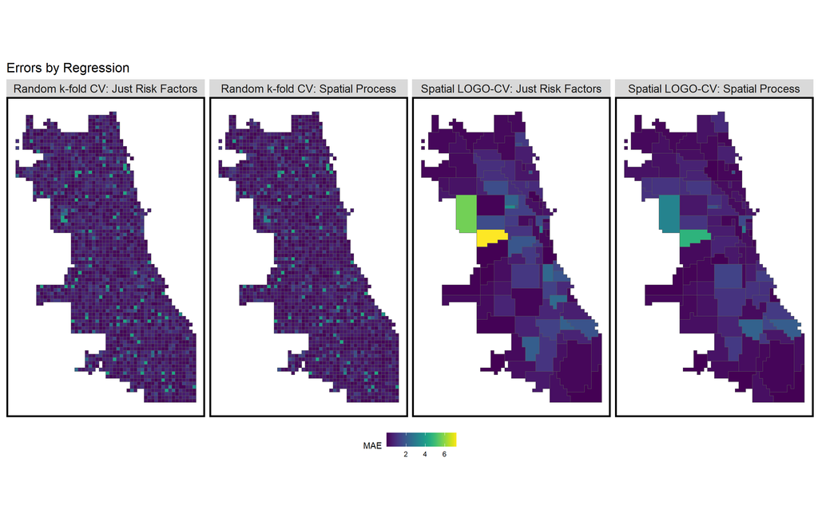

```r
error_by_reg_and_fold <-
  reg.summary  %>%
    group_by(Regression, cvID) %>%
    summarize(Mean_Error = mean(Prediction - countNarc, na.rm = T),
              MAE = mean(abs(Mean_Error), na.rm = T),
              SD_MAE = mean(abs(Mean_Error), na.rm = T)) %>%
  ungroup()

error_by_reg_and_fold %>%
  ggplot() +
  geom_sf(aes(fill = MAE)) +
  facet_wrap(~Regression, ncol = 4) +
  scale_fill_viridis() +
  labs(title = "Errors by Regression") +
  mapTheme() + theme(legend.position="bottom", #plot.title = element_text(size = 12)
                     )
```

The table provided below computes the average and standard deviation of errors categorized by regression. Notably, the mean and standard deviation of the mean absolute error (MAE) are reduced for the model featuring spatial process characteristics.

The “Random k-fold CV: Spatial Process” model appears to be the most accurate among the models, with the lowest average MAE. The “Spatial LOGO-CV: Just Risk Factors” model is the least accurate, with the highest average MAE. However, it’s essential to consider the SD values, as they reflect the variability in performance. A lower SD suggests more consistent results. Ultimately, you should choose the model that strikes a balance between low MAE and low SD for the most reliable and stable predictions.

This outcome aligns with our assessment that incorporating spatial process features enhances the model’s performance. It’s worth mentioning that the model seems to exhibit slightly reduced robustness during the spatial cross-validation.

```r
 st_drop_geometry(error_by_reg_and_fold) %>%
  group_by(Regression) %>%
  summarize(Mean_MAE = round(mean(MAE), 2),
            SD_MAE = round(sd(MAE), 2)) %>%
  kable(caption = "MAE by regression") %>%
  kable_styling() %>%
  kable_classic(html_font = "Helvetica", position = "left", full_width = FALSE)
```

MAE by regression

| Regression | Mean_MAE | SD_MAE |
| --- | --- | --- |
| Random k-fold CV: Just Risk Factors | 0.67 | 0.75 |
| Random k-fold CV: Spatial Process | 0.61 | 0.71 |
| Spatial LOGO-CV: Just Risk Factors | 0.87 | 1.12 |
| Spatial LOGO-CV: Spatial Process | 0.63 | 0.75 |

The table presents the results of two regression models, “Spatial LOGO-CV: Just Risk Factors” and “Spatial LOGO-CV: Spatial Process,” along with the calculated Moran’s I statistic and p-values for spatial autocorrelation.

Both models show positive Moran’s I values, which indicate the presence of spatial autocorrelation. The p-values in both cases are low, suggesting that this spatial autocorrelation is statistically significant. These results imply that the spatial distribution of the target variable in both models is not random, and there is a meaningful spatial pattern in the data.

```r
neighborhood.weights <-
  filter(error_by_reg_and_fold, Regression == "Spatial LOGO-CV: Spatial Process") %>%
    group_by(cvID) %>%
      poly2nb(as_Spatial(.), queen=TRUE) %>%
      nb2listw(., style="W", zero.policy=TRUE)

filter(error_by_reg_and_fold, str_detect(Regression, "LOGO"))  %>%
    st_drop_geometry() %>%
    group_by(Regression) %>%
    summarize(Morans_I = moran.mc(abs(Mean_Error), neighborhood.weights,
                                 nsim = 999, zero.policy = TRUE,
                                 na.action=na.omit)[[1]],
              p_value = moran.mc(abs(Mean_Error), neighborhood.weights,
                                 nsim = 999, zero.policy = TRUE,
                                 na.action=na.omit)[[3]]) %>%
    kable(caption = "MAE by regression") %>%
  kable_styling() %>%
  kable_classic(html_font = "Helvetica", position = "left", full_width = FALSE)
```

MAE by regression

| Regression | Morans_I | p_value |
| --- | --- | --- |
| Spatial LOGO-CV: Just Risk Factors | 0.2311142 | 0.004 |
| Spatial LOGO-CV: Spatial Process | 0.2044015 | 0.001 |

## Generalizability

To see if our model generalize across different neighborhood contexts, we pull race data by census tract. `percentWhite` is calculated and tracts are split into two groups, `Majority_White` and `Majority_Non_White`.

```r
tracts17 <-
  get_acs(geography = "tract", variables = c("B01001_001E","B01001A_001E"),
          year = 2017, state=17, county=031, geometry=T) %>%
  st_transform('ESRI:102271')  %>%
  dplyr::select(variable, estimate, GEOID) %>%
  spread(variable, estimate) %>%
  rename(TotalPop = B01001_001,
         NumberWhites = B01001A_001) %>%
  mutate(percentWhite = NumberWhites / TotalPop,
         raceContext = ifelse(percentWhite > .5, "Majority_White", "Majority_Non_White")) %>%
  .[neighborhoods,]
```

The map shows that Chicago is racially segregated.

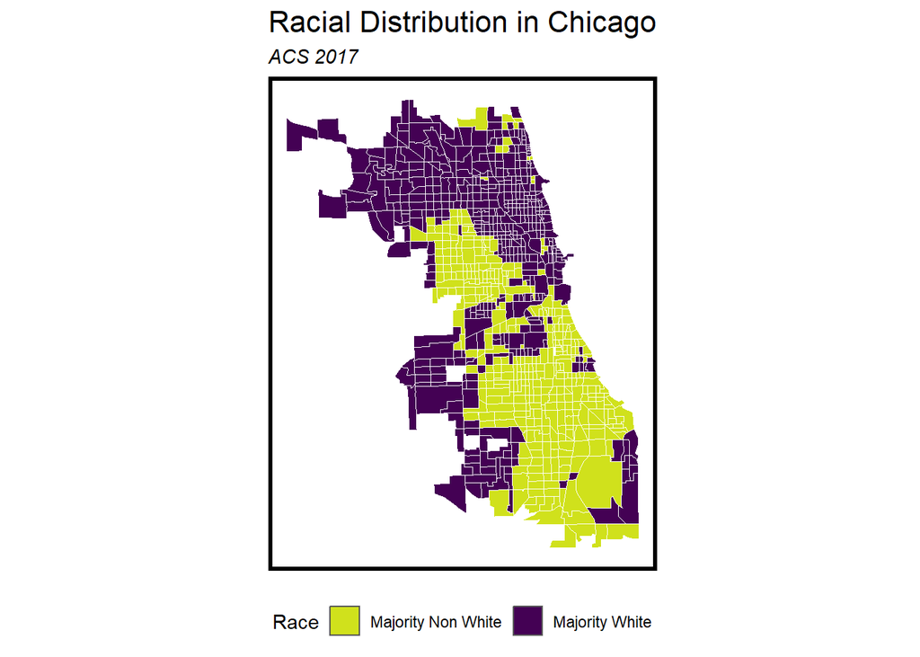

```r
ggplot() +
  geom_sf(data = na.omit(tracts17), aes(fill = raceContext)) +
  geom_sf(data = na.omit(tracts17), color = "white", fill = NA, , size = 0.1, alpha = 0.5) +
  scale_fill_manual(values = c("#d0e11c", "#440154"), name = "Race",
    labels = c("Majority Non White", "Majority White") ) +
  labs(title = "Racial Distribution in Chicago", subtitle = "ACS 2017") +
  mapTheme() +
  theme(legend.position = "bottom")
```

```r
#cat("CRS of tracts17: ", st_crs(tracts17)$proj4string, "\n")
#cat("CRS of narc_trans: ", st_crs(narc_trans)$proj4string, "\n")

#narc_trans <- st_transform(narc, crs = st_crs(tracts17))

#ggplot() +
#  geom_point(data = narc_trans, aes(x = Longitude, y = Latitude), color = "red", size = 0.5) +
#  labs(title = "Cannabis-Related Crime in Chicago") +
#  theme_minimal()

#ggplot() +
#  geom_sf(data = na.omit(tracts17), aes(fill = raceContext)) +
#  geom_sf(data = na.omit(tracts17), color = "white", fill = NA, size = 0.1, alpha = 0.5) +
#  geom_point(data = narc_trans, aes(x = Longitude, y = Latitude), color = "red", size = 0.5) +
#  scale_fill_manual(values = c("#d0e11c", "#365c8d"), name = "Race",
#    labels = c("Majority Non White", "Majority White")) +
#  labs(title = "Racial Distribution and Cannabis Crime in Chicago", subtitle = "ACS 2017") +
#  mapTheme() +
#  theme(legend.position = "bottom")
```

We now contrast the mean errors, calculated as the difference between predicted and observed values, for random `k-fold` and spatial `LOGO` cross-validation, taking into account the inclusion of spatial process features. As presented in the table, the model tends to underestimate the outcomes in ‘Majority Non-White’ neighborhoods while overestimating them in ‘Majority White’ neighborhoods.

```r
reg.summary %>%
    filter(str_detect(Regression, "Spatial Process")) %>%
    st_centroid() %>%
    st_join(tracts17) %>%
    na.omit() %>%
      st_drop_geometry() %>%
      group_by(Regression, raceContext) %>%
      summarize(mean.Error = mean(Error, na.rm = T)) %>%
      spread(raceContext, mean.Error) %>%
      kable(caption = "Mean Error by Neighborhood Racial Context") %>%
      kable_styling() %>%
      kable_classic(html_font = "Helvetica", position = "left", full_width = F)
```

Mean Error by Neighborhood Racial Context

| Regression | Majority_Non_White | Majority_White |
| --- | --- | --- |
| Random k-fold CV: Spatial Process | -0.1586954 | 0.1678321 |
| Spatial LOGO-CV: Spatial Process | -0.2358201 | 0.1793671 |

### Model Comparison

Police departments traditionally rely on kernel density hotspot mapping to guide their resource allocation. In our study, we seek to evaluate the performance of our spatial risk model in comparison to this conventional approach. To do so, we analyze risk predictions for next year’s crime generated by both models, and we present the results using a map that overlays the predictions on a dataset of 2018 narcotics-related crimes.

In our comparison, we classify the risk predictions into five different intervals using Fisher’s natural breaks classification.The ‘5th’ interval represents the **highest level of risk**, while the lowest risk level is depicted as the opposite.When examining the map, we observe that the predictions produced by the kernel density approach tend to be highly concentrated. This concentration may lead to an underestimation of crime risks in the peripheral areas surrounding crime hotspots.

On the other hand, our spatial risk model demonstrates a different pattern.It effectively accounts for the risks in the peripheral areas, resulting in more accurate risk estimates for these regions.

However, in the core crime hotspots, the spatial risk model appears to underpredict the risk. This discrepancy between the two models emphasizes the trade-offs between coverage and precision when dealing with crime risk predictions and allocation of police resources.

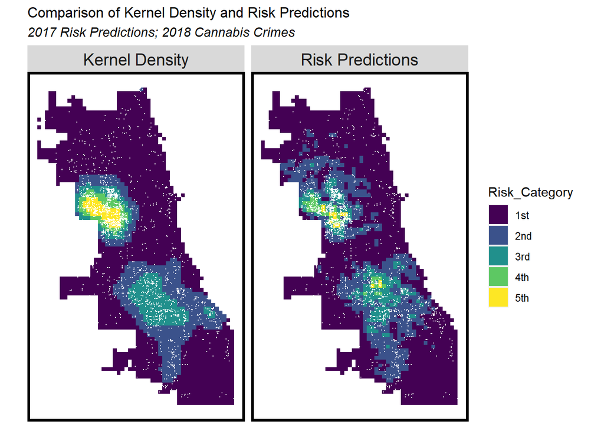

```r
narc_ppp <- as.ppp(st_coordinates(narc), W = st_bbox(final_net))
narc_KD.1000 <- density.ppp(narc_ppp, 1000)

narc18 <-
  read.socrata("https://data.cityofchicago.org/Public-Safety/Crimes-2018/3i3m-jwuy") %>%
  filter(Primary.Type == "NARCOTICS") %>%
  mutate(x = gsub("[()]", "", Location)) %>%
  separate(x,into= c("Y","X"), sep=",") %>%
  mutate(X = as.numeric(X),
         Y = as.numeric(Y)) %>%
  na.omit() %>%
  st_as_sf(coords = c("X", "Y"), crs = 4326, agr = "constant") %>%
  st_transform('ESRI:102271') %>%
  distinct() %>%
  .[fishnet,]


narc_KDE_sum <- as.data.frame(narc_KD.1000) %>%
  st_as_sf(coords = c("x", "y"), crs = st_crs(final_net)) %>%
  aggregate(., final_net, mean)
kde_breaks <- classIntervals(narc_KDE_sum$value,
                             n = 5, "fisher")
narc_KDE_sf <- narc_KDE_sum %>%
  mutate(label = "Kernel Density",
         Risk_Category = classInt::findCols(kde_breaks),
         Risk_Category = case_when(
           Risk_Category == 5 ~ "5th",
           Risk_Category == 4 ~ "4th",
           Risk_Category == 3 ~ "3rd",
           Risk_Category == 2 ~ "2nd",
           Risk_Category == 1 ~ "1st")) %>%
  cbind(
    aggregate(
      dplyr::select(narc18) %>% mutate(narcCount = 1), ., sum) %>%
    mutate(narcCount = replace_na(narcCount, 0))) %>%
  dplyr::select(label, Risk_Category, narcCount)


ml_breaks <- classIntervals(reg.ss.spatialCV$Prediction,
                             n = 5, "fisher")
narc_risk_sf <-
  reg.ss.spatialCV %>%
  mutate(label = "Risk Predictions",
         Risk_Category =classInt::findCols(ml_breaks),
         Risk_Category = case_when(
           Risk_Category == 5 ~ "5th",
           Risk_Category == 4 ~ "4th",
           Risk_Category == 3 ~ "3rd",
           Risk_Category == 2 ~ "2nd",
           Risk_Category == 1 ~ "1st")) %>%
  cbind(
    aggregate(
      dplyr::select(narc18) %>% mutate(narcCount = 1), ., sum) %>%
      mutate(narcCount = replace_na(narcCount, 0))) %>%
  dplyr::select(label,Risk_Category, narcCount)

rbind(narc_KDE_sf, narc_risk_sf) %>%
  na.omit() %>%
  gather(Variable, Value, -label, -Risk_Category, -geometry) %>%
  ggplot() +
    geom_sf(aes(fill = Risk_Category), colour = NA) +
    geom_sf(data = sample_n(narc18, 3000), size = .1, colour = "white") +
    facet_wrap(~label, ) +
    scale_fill_viridis(discrete = TRUE) +
    labs(title="Comparison of Kernel Density and Risk Predictions",
         subtitle="2017 Risk Predictions; 2018 Cannabis Crimes") +
    mapTheme(title_size = 12)
```

The bar plot shows how well two different models, the risk prediction model and the Kernel Density model, perform in predicting the risk of crimes in various categories. These categories are based on the level of risk, with the highest risk category being the most dangerous.

The plot compares the number of actual 2018 crimes that fall into these risk categories as predicted by each model. Ideally, a well-fitting model should capture a larger portion of the 2018 crimes in the highest risk category, indicating that it can accurately identify and predict high-risk areas.

The risk prediction model outperforms the Kernel Density model in the first, second, and third risk categories. However, it doesn’t perform as well as the Kernel Density model in the highest risk category. This suggests that the risk prediction model is effective at identifying and predicting risks in some scenarios but needs further improvement to better predict in the most “dangerous” areas.

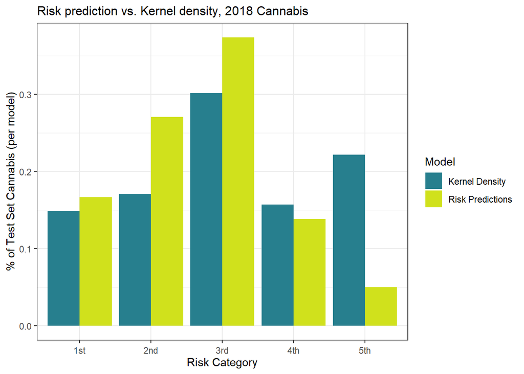

```r
rbind(narc_KDE_sf, narc_risk_sf) %>%
  st_drop_geometry() %>%
  na.omit() %>%
  gather(Variable, Value, -label, -Risk_Category) %>%
  group_by(label, Risk_Category) %>%
  summarize(countNarc = sum(Value)) %>%
  ungroup() %>%
  group_by(label) %>%
  mutate(Pcnt_of_test_set_crimes = countNarc / sum(countNarc)) %>%
  ggplot(aes(Risk_Category, Pcnt_of_test_set_crimes, fill = label)) +
  geom_bar(position = "dodge", stat = "identity") +
  scale_fill_manual(values = c("#277f8e", "#d0e11c"), name = "Model") +
  labs(title = "Risk prediction vs. Kernel density, 2018 Cannabis",
       y = "% of Test Set Cannabis (per model)",
       x = "Risk Category") +
  theme_bw() +
  theme(axis.text.x = element_text(vjust = 0.5),
        plot.title = element_text(size = 12))
```

## Recommendation

Moreover, there are other considerations that discourage the adoption of this algorithm. When compared to the traditional kernel density model, the spatial risk model does not perform well in accurately identifying the riskiest areas of narcotics-related crimes. Additionally, the errors by regression map indicate the presence of larger mean absolute errors in crime hotspots, suggesting potential spatial autocorrelation. This signifies the need for further feature engineering to comprehensively explain the underlying spatial processes.

Therefore, I **recommend exercising caution** and refraining from implementation of this algorithm in police departments until biases and the spatial processes of crimes are thoroughly scrutinized and addressed.

### References

Public Policy Analytics: Code & Context for Data Science in Government https://urbanspatial.github.io/PublicPolicyAnalytics/index.html